# CourseDataAnalysis_templateTest

Franziska Greulich

2022-08-25

# Working with peaks in R (data analysis from the Helmholtz Chromatin Summer School 2022)

### Retrieve your RAW data and store it in the “./data” folder of your project.

Have a look at the “./data” folder within the project on GitLab () and download all replicates of one sample into “./data” folder of your project. You can download the data from within R using the `download.file` function from the `RCurl` package. For this copy the URL into `url`. **Note** You need the “RAW” data URL from GitHub/GitLab. However, the data has to be public or you need to generate a access token for each file. Alternatively, grep the data from the HPC (not possible via R) and store it in your “./data” folder.  
**Note**: Those files are in .narrowPeak format.

```r
#as example: download a file from GitHub from R
#library(RCurl)

#url <- "https://raw.githubusercontent.com/FranziG/Working-with-Peaks-in-R/master/data/MACS/hMonocytes_4h1uMTA_aGR_rep1_SRR6497267overSRR6497265_SE_hg38_FDR005_peaks.narrowPeak"
#download.file(url, destfile = "./data", method = "curl")

#read input data in narrowPeak format: Example of a _peaks.narrowPeak MACS output.
rep1 <- read.table("./data/MACS/ATAC_1_peaks.narrowPeak", header = FALSE, sep = '\t', stringsAsFactors = FALSE)

#Look at the first 10 lines of replicate 1
head(rep1, 10)
```

```
##      V1     V2     V3             V4  V5 V6       V7       V8       V9 V10
## 1  chr1 778420 778915  ATAC_1_peak_1 317  . 15.43750 34.89420 31.77790 244
## 2  chr1 845745 845897  ATAC_1_peak_2  64  .  5.78907  8.74254  6.41567  90
## 3  chr1 869805 870043  ATAC_1_peak_3  54  .  5.30664  7.69070  5.41993  48
## 4  chr1 904630 904855  ATAC_1_peak_4  64  .  5.78907  8.74254  6.41567 121
## 5  chr1 905373 905514  ATAC_1_peak_5  35  .  4.34180  5.70203  3.55966  68
## 6  chr1 917154 917268  ATAC_1_peak_6  19  .  3.37696  3.89308  1.92894   1
## 7  chr1 919619 919806  ATAC_1_peak_7  27  .  3.85938  4.77271  2.70965 138
## 8  chr1 921129 921339  ATAC_1_peak_8  44  .  4.82422  6.67606  4.46587 154
## 9  chr1 923089 923212  ATAC_1_peak_9  35  .  4.34180  5.70203  3.55966  32
## 10 chr1 923728 924328 ATAC_1_peak_10  54  .  5.30664  7.69070  5.41993 240
```

```r
#Assign column names.
colnames(rep1) <- c("chr","start","end","name","score","strand","fold-change","pvalue_log10","qvalue_log10","summit")

#which chromosomes are in our data
print("List of chromosome names:")
```

```
## [1] "List of chromosome names:"
```

```r
unique(rep1$chr)
```

```
##  [1] "chr1"                    "chr10"
##  [3] "chr10_GL383545v1_alt"    "chr11"
##  [5] "chr11_KI270830v1_alt"    "chr12"
##  [7] "chr12_GL877875v1_alt"    "chr13"
##  [9] "chr14"                   "chr14_GL000194v1_random"
## [11] "chr14_GL000225v1_random" "chr14_KI270845v1_alt"
## [13] "chr14_KI270846v1_alt"    "chr15"
## [15] "chr16"                   "chr16_KI270728v1_random"
## [17] "chr17"                   "chr17_GL000205v2_random"
## [19] "chr18"                   "chr19"
## [21] "chr1_KI270712v1_random"  "chr1_KI270713v1_random"
## [23] "chr2"                    "chr20"
## [25] "chr21"                   "chr21_GL383578v2_alt"
## [27] "chr21_GL383580v2_alt"    "chr22"
## [29] "chr22_KI270733v1_random" "chr22_KI270736v1_random"
```

[output cut: 16 more lines]

```r
#How many peaks are within your data?
print(paste("Number of peaks before filtering:",nrow(rep1),sep=" "))
```

```
## [1] "Number of peaks before filtering: 107324"
```

```r
#remove al xhromosomes from patches and mitochondria
#1. define a vector of human chromosome names
chrHs <- c("chr1","chr2","chr3","chr4","chr5","chr6","chr7","chr8","chr9","chr10","chr11","chr12","chr13","chr14","chr15","chr16","chr17","chr18","chr19","chr20","chr21","chr22","chrX","chrY")

#filter
rep1 <- rep1[rep1$chr%in%chrHs,]

print("Remaining chromosomes after filtering:")
```

```
## [1] "Remaining chromosomes after filtering:"
```

```r
unique(rep1$chr)
```

```
##  [1] "chr1"  "chr10" "chr11" "chr12" "chr13" "chr14" "chr15" "chr16" "chr17"
## [10] "chr18" "chr19" "chr2"  "chr20" "chr21" "chr22" "chr3"  "chr4"  "chr5"
## [19] "chr6"  "chr7"  "chr8"  "chr9"  "chrX"  "chrY"
```

```r
#How many peaks remain in your data after filtering?
print(paste("Number of peaks after filtering:",nrow(rep1),sep=" "))
```

```
## [1] "Number of peaks after filtering: 107230"
```

Rather then copy-pasting the same code for every replicate you may use loops to efficiently apply the same function repeatedly to different elements of a data object in R.

```r
#for repeated operations you can use FOR loops or better the apply function of R
# we need a list of our samples first
samples <- list.files(path = "./data/MACS/", pattern = "ATAC")

#add the path to your file names
samples <- paste("./data/MACS/",samples,sep="")

#import peaks
peaks <- lapply(samples, function(x) read.table(x, header = FALSE, stringsAsFactors = FALSE, sep="\t"))


#Have a look at the structure of peaks
str(peaks)
```

```
## List of 6
##  $ :'data.frame':    107324 obs. of  10 variables:
##   ..$ V1 : chr [1:107324] "chr1" "chr1" "chr1" "chr1" ...
##   ..$ V2 : int [1:107324] 778420 845745 869805 904630 905373 917154 919619 921129 923089 923728 ...
##   ..$ V3 : int [1:107324] 778915 845897 870043 904855 905514 917268 919806 921339 923212 924328 ...
##   ..$ V4 : chr [1:107324] "ATAC_1_peak_1" "ATAC_1_peak_2" "ATAC_1_peak_3" "ATAC_1_peak_4" ...
##   ..$ V5 : int [1:107324] 317 64 54 64 35 19 27 44 35 54 ...
##   ..$ V6 : chr [1:107324] "." "." "." "." ...
##   ..$ V7 : num [1:107324] 15.44 5.79 5.31 5.79 4.34 ...
##   ..$ V8 : num [1:107324] 34.89 8.74 7.69 8.74 5.7 ...
##   ..$ V9 : num [1:107324] 31.78 6.42 5.42 6.42 3.56 ...
##   ..$ V10: int [1:107324] 244 90 48 121 68 1 138 154 32 240 ...
##  $ :'data.frame':    136387 obs. of  10 variables:
##   ..$ V1 : chr [1:136387] "chr1" "chr1" "chr1" "chr1" ...
##   ..$ V2 : int [1:136387] 778396 779169 827393 845559 869779 904444 908283 910514 913000 916688 ...
##   ..$ V3 : int [1:136387] 779002 779365 827773 845981 870215 904977 908451 910727 913387 917642 ...
##   ..$ V4 : chr [1:136387] "ATAC_2_peak_1" "ATAC_2_peak_2" "ATAC_2_peak_3" "ATAC_2_peak_4" ...
##   ..$ V5 : int [1:136387] 1117 21 172 323 309 323 13 21 67 111 ...
##   ..$ V6 : chr [1:136387] "." "." "." "." ...
##   ..$ V7 : num [1:136387] 37.96 3.36 10.09 15.38 14.89 ...
##   ..$ V8 : num [1:136387] 114.73 3.87 19.44 34.79 33.32 ...
##   ..$ V9 : num [1:136387] 111.71 2.11 17.21 32.36 30.9 ...
##   ..$ V10: int [1:136387] 263 24 104 242 172 297 120 26 41 397 ...
##  $ :'data.frame':    140659 obs. of  10 variables:
##   ..$ V1 : chr [1:140659] "chr1" "chr1" "chr1" "chr1" ...
##   ..$ V2 : int [1:140659] 778367 827402 845655 869518 904405 908217 910669 912639 916550 918474 ...
##   ..$ V3 : int [1:140659] 779019 827741 845948 870185 904851 908453 911014 913276 917984 919270 ...
##   ..$ V4 : chr [1:140659] "ATAC_3_peak_1" "ATAC_3_peak_2" "ATAC_3_peak_3" "ATAC_3_peak_4" ...
##   ..$ V5 : int [1:140659] 1388 190 332 401 291 35 52 178 70 61 ...
##   ..$ V6 : chr [1:140659] "." "." "." "." ...
##   ..$ V7 : num [1:140659] 39.75 9.84 14.17 16.14 12.99 ...
##   ..$ V8 : num [1:140659] 141.7 21.1 35.5 42.5 31.4 ...
##   ..$ V9 : num [1:140659] 138.8 19 33.2 40.2 29.2 ...
##   ..$ V10: int [1:140659] 371 155 191 359 338 214 178 371 197 502 ...
##  $ :'data.frame':    139275 obs. of  10 variables:
##   ..$ V1 : chr [1:139275] "chr1" "chr1" "chr1" "chr1" ...
##   ..$ V2 : int [1:139275] 778375 779687 827391 845717 869669 904086 912735 916413 917566 918348 ...
##   ..$ V3 : int [1:139275] 778970 779961 827776 845926 870200 905017 913080 917391 918023 918529 ...
##   ..$ V4 : chr [1:139275] "ATAC_4_peak_1" "ATAC_4_peak_2" "ATAC_4_peak_3" "ATAC_4_peak_4" ...
##   ..$ V5 : int [1:139275] 1204 149 228 373 435 313 137 90 39 14 ...
```

[output cut: 12 more lines]

```
##   ..$ V7 : num [1:155006] 39.8 10.5 10.5 11.2 18.8 ...
##   ..$ V8 : num [1:155006] 164.3 26.4 26.4 28.8 59.8 ...
##   ..$ V9 : num [1:155006] 161.4 24.2 24.2 26.6 57.4 ...
##   ..$ V10: int [1:155006] 339 184 158 115 201 743 185 226 685 99 ...
##  $ :'data.frame':    123316 obs. of  10 variables:
##   ..$ V1 : chr [1:123316] "chr1" "chr1" "chr1" "chr1" ...
##   ..$ V2 : int [1:123316] 778391 779790 827375 845681 869774 904451 916560 916931 918711 920464 ...
##   ..$ V3 : int [1:123316] 778965 779939 827741 845932 870171 905018 916705 917401 919053 921668 ...
##   ..$ V4 : chr [1:123316] "ATAC_6_peak_1" "ATAC_6_peak_2" "ATAC_6_peak_3" "ATAC_6_peak_4" ...
##   ..$ V5 : int [1:123316] 755 60 223 263 304 223 41 50 60 223 ...
##   ..$ V6 : chr [1:123316] "." "." "." "." ...
##   ..$ V7 : num [1:123316] 27.19 5.35 11.59 12.93 14.27 ...
##   ..$ V8 : num [1:123316] 78.47 8.04 24.67 28.73 32.92 ...
##   ..$ V9 : num [1:123316] 75.57 6.04 22.31 26.31 30.45 ...
##   ..$ V10: int [1:123316] 268 85 108 120 115 303 106 156 200 759 ...
```

```r
#have a look at the first list element
head(peaks[[1]])
```

```
##     V1     V2     V3            V4  V5 V6       V7       V8       V9 V10
## 1 chr1 778420 778915 ATAC_1_peak_1 317  . 15.43750 34.89420 31.77790 244
## 2 chr1 845745 845897 ATAC_1_peak_2  64  .  5.78907  8.74254  6.41567  90
## 3 chr1 869805 870043 ATAC_1_peak_3  54  .  5.30664  7.69070  5.41993  48
## 4 chr1 904630 904855 ATAC_1_peak_4  64  .  5.78907  8.74254  6.41567 121
## 5 chr1 905373 905514 ATAC_1_peak_5  35  .  4.34180  5.70203  3.55966  68
## 6 chr1 917154 917268 ATAC_1_peak_6  19  .  3.37696  3.89308  1.92894   1
```

```r
#Show top rows of all list elements
lapply(peaks,head)
```

```
## [[1]]
##     V1     V2     V3            V4  V5 V6       V7       V8       V9 V10
## 1 chr1 778420 778915 ATAC_1_peak_1 317  . 15.43750 34.89420 31.77790 244
## 2 chr1 845745 845897 ATAC_1_peak_2  64  .  5.78907  8.74254  6.41567  90
## 3 chr1 869805 870043 ATAC_1_peak_3  54  .  5.30664  7.69070  5.41993  48
## 4 chr1 904630 904855 ATAC_1_peak_4  64  .  5.78907  8.74254  6.41567 121
## 5 chr1 905373 905514 ATAC_1_peak_5  35  .  4.34180  5.70203  3.55966  68
## 6 chr1 917154 917268 ATAC_1_peak_6  19  .  3.37696  3.89308  1.92894   1
##
## [[2]]
##     V1     V2     V3            V4   V5 V6       V7        V8        V9 V10
## 1 chr1 778396 779002 ATAC_2_peak_1 1117  . 37.95730 114.73400 111.71300 263
## 2 chr1 779169 779365 ATAC_2_peak_2   21  .  3.36331   3.87249   2.10988  24
## 3 chr1 827393 827773 ATAC_2_peak_3  172  . 10.08990  19.44340  17.21430 104
## 4 chr1 845559 845981 ATAC_2_peak_4  323  . 15.37510  34.78920  32.35540 242
## 5 chr1 869779 870215 ATAC_2_peak_5  309  . 14.89460  33.31760  30.90030 172
## 6 chr1 904444 904977 ATAC_2_peak_6  323  . 15.37510  34.78920  32.35540 297
##
## [[3]]
##     V1     V2     V3            V4   V5 V6       V7        V8        V9 V10
## 1 chr1 778367 779019 ATAC_3_peak_1 1388  . 39.74920 141.67100 138.81100 371
## 2 chr1 827402 827741 ATAC_3_peak_2  190  .  9.83892  21.13880  19.03920 155
## 3 chr1 845655 845948 ATAC_3_peak_3  332  . 14.16800  35.46110  33.20660 191
## 4 chr1 869518 870185 ATAC_3_peak_4  401  . 16.13580  42.47830  40.16370 359
## 5 chr1 904405 904851 ATAC_3_peak_5  291  . 12.98740  31.39090  29.17490 338
## 6 chr1 908217 908453 ATAC_3_peak_6   35  .  3.93557   5.28652   3.53368 214
##
## [[4]]
##     V1     V2     V3            V4   V5 V6       V7       V8       V9 V10
## 1 chr1 778375 778970 ATAC_4_peak_1 1204  . 40.55640 123.4060 120.4170 284
## 2 chr1 779687 779961 ATAC_4_peak_2  149  .  9.28399  17.1410  14.9979 222
## 3 chr1 827391 827776 ATAC_4_peak_3  228  . 12.21580  25.1335  22.8715 173
## 4 chr1 845717 845926 ATAC_4_peak_4  373  . 17.10210  39.7646  37.3403  84
## 5 chr1 869669 870200 ATAC_4_peak_5  435  . 19.05660  45.9822  43.5006 220
## 6 chr1 904086 905017 ATAC_4_peak_6  313  . 15.14760  33.7427  31.3796 637
##
## [[5]]
##     V1     V2     V3            V4   V5 V6      V7       V8       V9 V10
## 1 chr1 778399 778978 ATAC_5_peak_1 1613  . 39.8075 164.3310 161.3890 339
## 2 chr1 779691 779964 ATAC_5_peak_2  242  . 10.5276  26.3727  24.2167 184
## 3 chr1 827399 827670 ATAC_5_peak_3  242  . 10.5276  26.3727  24.2167 158
## 4 chr1 845686 845948 ATAC_5_peak_4  266  . 11.1856  28.8052  26.6223 115
## 5 chr1 869688 870207 ATAC_5_peak_5  573  . 18.7523  59.8336  57.3966 201
## 6 chr1 903980 904873 ATAC_5_peak_6  407  . 14.8044  43.0141  40.7003 743
##
## [[6]]
##     V1     V2     V3            V4  V5 V6       V7       V8      V9 V10
## 1 chr1 778391 778965 ATAC_6_peak_1 755  . 27.19320 78.46950 75.5687 268
## 2 chr1 779790 779939 ATAC_6_peak_2  60  .  5.34949  8.04242  6.0427  85
## 3 chr1 827375 827741 ATAC_6_peak_3 223  . 11.59060 24.66700 22.3094 108
## 4 chr1 845681 845932 ATAC_6_peak_4 263  . 12.92790 28.72640 26.3105 120
## 5 chr1 869774 870171 ATAC_6_peak_5 304  . 14.26530 32.91800 30.4473 115
## 6 chr1 904451 905018 ATAC_6_peak_6 223  . 11.59060 24.66700 22.3094 303
```

```r
#assign a name to each list element
names(peaks) <- list.files("./data/MACS/",pattern="ATAC",full.names=FALSE)

#Which chomosomes ar in your data?
for (i in 1:length(peaks)) {
  print(paste("Chromosomes in",names(peaks)[i],":",unique(peaks[[i]][1]),sep=" "))
}
```

```
## [1] "Chromosomes in ATAC_1_peaks.narrowPeak : c(\"chr1\", \"chr10\", \"chr10_GL383545v1_alt\", \"chr11\", \"chr11_KI270830v1_alt\", \"chr12\", \"chr12_GL877875v1_alt\", \"chr13\", \"chr14\", \"chr14_GL000194v1_random\", \"chr14_GL000225v1_random\", \"chr14_KI270845v1_alt\", \"chr14_KI270846v1_alt…
## [1] "Chromosomes in ATAC_2_peaks.narrowPeak : c(\"chr1\", \"chr10\", \"chr10_GL383545v1_alt\", \"chr11\", \"chr11_KI270830v1_alt\", \"chr12\", \"chr12_GL877875v1_alt\", \"chr13\", \"chr14\", \"chr14_GL000225v1_random\", \"chr14_KI270726v1_random\", \"chr14_KI270845v1_alt\", \"chr14_KI270846v1_alt…
## [1] "Chromosomes in ATAC_3_peaks.narrowPeak : c(\"chr1\", \"chr10\", \"chr10_GL383545v1_alt\", \"chr11\", \"chr11_KI270830v1_alt\", \"chr12\", \"chr12_GL877875v1_alt\", \"chr13\", \"chr14\", \"chr14_GL000009v2_random\", \"chr14_KI270845v1_alt\", \"chr14_KI270846v1_alt\", \"chr15\", \"chr15_KI2708…
## [1] "Chromosomes in ATAC_4_peaks.narrowPeak : c(\"chr1\", \"chr10\", \"chr10_GL383545v1_alt\", \"chr11\", \"chr11_KI270830v1_alt\", \"chr11_KI270832v1_alt\", \"chr12\", \"chr12_GL877875v1_alt\", \"chr13\", \"chr14\", \"chr14_GL000009v2_random\", \"chr14_GL000194v1_random\", \"chr14_GL000225v1_ran…
## [1] "Chromosomes in ATAC_5_peaks.narrowPeak : c(\"chr1\", \"chr10\", \"chr10_GL383545v1_alt\", \"chr11\", \"chr11_KI270830v1_alt\", \"chr12\", \"chr13\", \"chr14\", \"chr14_GL000009v2_random\", \"chr14_GL000194v1_random\", \"chr14_GL000225v1_random\", \"chr14_KI270845v1_alt\", \"chr14_KI270846v1_…
## [1] "Chromosomes in ATAC_6_peaks.narrowPeak : c(\"chr1\", \"chr10\", \"chr10_GL383545v1_alt\", \"chr11\", \"chr11_KI270830v1_alt\", \"chr12\", \"chr13\", \"chr14\", \"chr14_GL000009v2_random\", \"chr14_GL000194v1_random\", \"chr14_GL000225v1_random\", \"chr14_KI270726v1_random\", \"chr14_KI270845…
```

```r
#How many peaks are in your samples?
npeaks_before <- vector()
for (i in 1:length(peaks)) {
  print(paste(names(peaks)[i],nrow(peaks[[i]]),sep=": "))
  npeaks_before <- c(npeaks_before,nrow(peaks[[i]]))
}
```

```
## [1] "ATAC_1_peaks.narrowPeak: 107324"
## [1] "ATAC_2_peaks.narrowPeak: 136387"
## [1] "ATAC_3_peaks.narrowPeak: 140659"
## [1] "ATAC_4_peaks.narrowPeak: 139275"
## [1] "ATAC_5_peaks.narrowPeak: 155006"
## [1] "ATAC_6_peaks.narrowPeak: 123316"
```

```r
names(npeaks_before) <- names(peaks)

#remove non-classical chromosomes
#1. define a vector of human chromosome names
chrHs <- c("chr1","chr2","chr3","chr4","chr5","chr6","chr7","chr8","chr9","chr10","chr11","chr12","chr13","chr14","chr15","chr16","chr17","chr18","chr19","chr20","chr21","chr22","chrX","chrY")
#filter
peaks <- lapply(peaks, FUN = function (x) { x[x$V1%in%chrHs,] } )

#How many peaks remain after filtering unconventional chromosomes? What is the percentage?

for (i in 1:length(peaks)) {
  perc <- 100-100*nrow(peaks[[i]])/npeaks_before[i]
  print(paste(names(peaks)[i],":",nrow(peaks[[i]]),"; Percent of removed peaks:",round(perc,3),"%",sep=" "))
}
```

```
## [1] "ATAC_1_peaks.narrowPeak : 107230 ; Percent of removed peaks: 0.088 %"
## [1] "ATAC_2_peaks.narrowPeak : 136295 ; Percent of removed peaks: 0.067 %"
## [1] "ATAC_3_peaks.narrowPeak : 140581 ; Percent of removed peaks: 0.055 %"
## [1] "ATAC_4_peaks.narrowPeak : 139191 ; Percent of removed peaks: 0.06 %"
## [1] "ATAC_5_peaks.narrowPeak : 154892 ; Percent of removed peaks: 0.074 %"
## [1] "ATAC_6_peaks.narrowPeak : 123215 ; Percent of removed peaks: 0.082 %"
```

### Convert peaks into GRanges.  
A `GRange` object (from the `GenomicRanges` package) is an useful data type to store genomic locations and annotations. In order to make things easier, we define a function `bed2GRanges` that converts or imported tab-delimited data into a `GRange` object using the `GRanges` function from the `GenomicRanges` package. The minimal composition of a `GRange` object consists of `seqnames` holding the chromosome name and an `IRanges` object holding start and end coordinates as well as the strand information of the DNA sequence. Additional data can be provided as metadata columns.

#### 1. Load the `GenomicRanges` package into R.

```r
library("GenomicRanges")
```

#### 2. Define a function `bed2GRanges` to convert data frames into `GRanges`.

**Note**: ChIP experiments are unstranded. Set the strand to “*“. **Note**: If the peaks do not have specified names, you can generate unique names pasting chr, start and end.

```r
bed2GRanges <-function(peaks)
{
  myrange <- GRanges(seqnames = peaks[,1],range = IRanges(start = peaks[,2], end = peaks[,3], names = peaks[,4]), strand = "*")
  return(myrange)
}
```

#### 3. Convert the data frame containing your single replicate from above into a GRange object and look at the structue of the `GRange` object.

```r
#convert the filtered narrow peak file into a GRange object.
rep1_g <- bed2GRanges(rep1)

#Have a look at the GRange structure.
str(rep1_g)
```

```
## Formal class 'GRanges' [package "GenomicRanges"] with 7 slots
##   ..@ seqnames       :Formal class 'Rle' [package "S4Vectors"] with 4 slots
##   .. .. ..@ values         : Factor w/ 24 levels "chr1","chr10",..: 1 2 3 4 5 6 7 8 9 10 ...
##   .. .. ..@ lengths        : int [1:24] 10772 3613 4633 4693 1308 5033 3448 4931 6369 743 ...
##   .. .. ..@ elementMetadata: NULL
##   .. .. ..@ metadata       : list()
##   ..@ ranges         :Formal class 'IRanges' [package "IRanges"] with 6 slots
##   .. .. ..@ start          : int [1:107230] 778420 845745 869805 904630 905373 917154 919619 921129 923089 923728 ...
##   .. .. ..@ width          : int [1:107230] 496 153 239 226 142 115 188 211 124 601 ...
##   .. .. ..@ NAMES          : chr [1:107230] "ATAC_1_peak_1" "ATAC_1_peak_2" "ATAC_1_peak_3" "ATAC_1_peak_4" ...
##   .. .. ..@ elementType    : chr "ANY"
##   .. .. ..@ elementMetadata: NULL
##   .. .. ..@ metadata       : list()
##   ..@ strand         :Formal class 'Rle' [package "S4Vectors"] with 4 slots
##   .. .. ..@ values         : Factor w/ 3 levels "+","-","*": 3
##   .. .. ..@ lengths        : int 107230
##   .. .. ..@ elementMetadata: NULL
##   .. .. ..@ metadata       : list()
##   ..@ seqinfo        :Formal class 'Seqinfo' [package "GenomeInfoDb"] with 4 slots
##   .. .. ..@ seqnames   : chr [1:24] "chr1" "chr10" "chr11" "chr12" ...
##   .. .. ..@ seqlengths : int [1:24] NA NA NA NA NA NA NA NA NA NA ...
##   .. .. ..@ is_circular: logi [1:24] NA NA NA NA NA NA ...
##   .. .. ..@ genome     : chr [1:24] NA NA NA NA ...
##   ..@ elementMetadata:Formal class 'DFrame' [package "S4Vectors"] with 6 slots
##   .. .. ..@ rownames       : NULL
##   .. .. ..@ nrows          : int 107230
##   .. .. ..@ elementType    : chr "ANY"
##   .. .. ..@ elementMetadata: NULL
##   .. .. ..@ metadata       : list()
##   .. .. ..@ listData       : Named list()
##   ..@ elementType    : chr "ANY"
##   ..@ metadata       : list()
```

```r
head(rep1_g)
```

```
## GRanges object with 6 ranges and 0 metadata columns:
##                 seqnames        ranges strand
##                    <Rle>     <IRanges>  <Rle>
##   ATAC_1_peak_1     chr1 778420-778915      *
##   ATAC_1_peak_2     chr1 845745-845897      *
##   ATAC_1_peak_3     chr1 869805-870043      *
##   ATAC_1_peak_4     chr1 904630-904855      *
##   ATAC_1_peak_5     chr1 905373-905514      *
##   ATAC_1_peak_6     chr1 917154-917268      *
##   -------
##   seqinfo: 24 sequences from an unspecified genome; no seqlengths
```

#### 4. Provide a metadata column `FC` containing the `fold-change` and a `qvalue` column to the `GRange` object by defining a function `narrow2GRanges` similar to the `bed2GRanges` function.

```r
narrow2GRanges <-function(peaks)
{
  myrange <- GRanges(seqnames = peaks[,1],range = IRanges(start = peaks[,2], end = peaks[,3], names = peaks[,4]), strand = "*",FC = peaks[,7], qvalue = peaks[,9])
  return(myrange)
}
rep1_g <- narrow2GRanges(rep1)

head(rep1_g)
```

```
## GRanges object with 6 ranges and 2 metadata columns:
##                 seqnames        ranges strand |        FC    qvalue
##                    <Rle>     <IRanges>  <Rle> | <numeric> <numeric>
##   ATAC_1_peak_1     chr1 778420-778915      * |  15.43750  31.77790
##   ATAC_1_peak_2     chr1 845745-845897      * |   5.78907   6.41567
##   ATAC_1_peak_3     chr1 869805-870043      * |   5.30664   5.41993
##   ATAC_1_peak_4     chr1 904630-904855      * |   5.78907   6.41567
##   ATAC_1_peak_5     chr1 905373-905514      * |   4.34180   3.55966
##   ATAC_1_peak_6     chr1 917154-917268      * |   3.37696   1.92894
##   -------
##   seqinfo: 24 sequences from an unspecified genome; no seqlengths
```

In order to access information stored in `GRanges` objects, the `GenomicRanges` package provides some accessor functions.

#### 5. Extract metadata using the accessor function `mcols`. Save the fold-changed in a seperate vector foldChange.

```r
#Metadata
mcols(rep1_g)
```

```
## DataFrame with 107230 rows and 2 columns
##                           FC    qvalue
##                    <numeric> <numeric>
## ATAC_1_peak_1       15.43750  31.77790
## ATAC_1_peak_2        5.78907   6.41567
## ATAC_1_peak_3        5.30664   5.41993
## ATAC_1_peak_4        5.78907   6.41567
## ATAC_1_peak_5        4.34180   3.55966
## ...                      ...       ...
## ATAC_1_peak_107320   5.78907   6.41567
## ATAC_1_peak_107321   3.37696   1.92894
## ATAC_1_peak_107322   4.34180   3.55966
## ATAC_1_peak_107323   8.20118  11.90050
## ATAC_1_peak_107324   3.85938   2.70965
```

```r
#Fold-change
foldChange <- mcols(rep1_g)$FC
```

#### 6. Extract the genomic locations from the `GRange` object of your replicate with `granges`.

```r
granges(rep1_g)
```

```
## GRanges object with 107230 ranges and 0 metadata columns:
##                      seqnames              ranges strand
##                         <Rle>           <IRanges>  <Rle>
##        ATAC_1_peak_1     chr1       778420-778915      *
##        ATAC_1_peak_2     chr1       845745-845897      *
##        ATAC_1_peak_3     chr1       869805-870043      *
##        ATAC_1_peak_4     chr1       904630-904855      *
##        ATAC_1_peak_5     chr1       905373-905514      *
##                  ...      ...                 ...    ...
##   ATAC_1_peak_107320     chrX 155395040-155395159      *
##   ATAC_1_peak_107321     chrX 155577564-155577731      *
##   ATAC_1_peak_107322     chrX 155578328-155578563      *
##   ATAC_1_peak_107323     chrX 155612391-155613071      *
##   ATAC_1_peak_107324     chrY   11295559-11295718      *
##   -------
##   seqinfo: 24 sequences from an unspecified genome; no seqlengths
```

Let’s extract practice handling GRAnges object a bit more by extracting relevant information.

#### 7. How many peaks are contained in your selected replicate?

```r
length(rep1_g)
```

```
## [1] 107230
```

#### 8. How does the peak size distribution look like? Plot a histogram and report the minimal and maximal peak width. Do you observe any abnormalities?

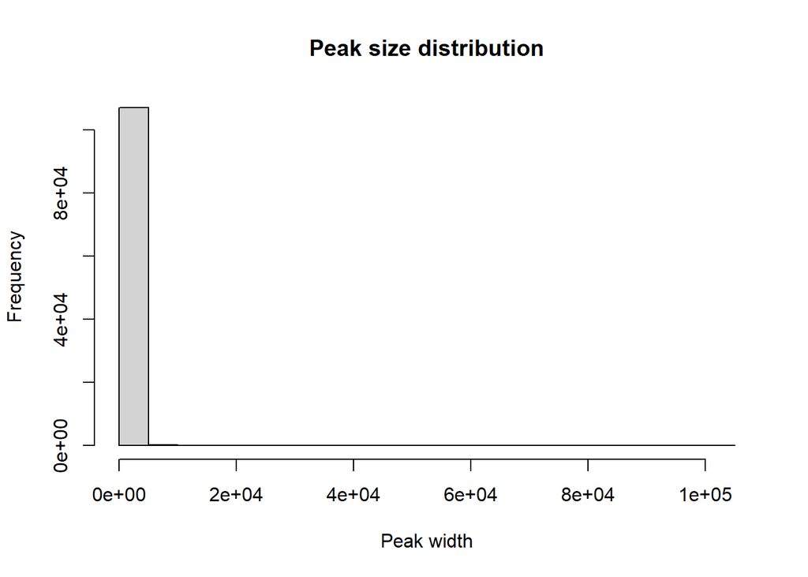

```r
hist(width(rep1_g), main = "Peak size distribution", xlab = "Peak width")
```

```r
print(paste("The maximal peak with within replicate 1 of ATACseq is:",max(width(rep1_g)),sep=" "))
```

```
## [1] "The maximal peak with within replicate 1 of ATACseq is: 101896"
```

```r
print(paste("The minimal peak with within replicate 1 of ATACseq is:",min(width(rep1_g)),sep=" "))
```

```
## [1] "The minimal peak with within replicate 1 of ATACseq is: 114"
```

The `plyranges` package from Stuart Lee (https://genomebiology.biomedcentral.com/articles/10.1186/s13059-018-1597-8) offers the posibility to filter `GRanges` analog to the `dplyr` package for data frame using the same function names. Although the `plyranges` package automatiacally detects the data type, writing `plyranges::` in front of the function names avoids errors due to namespace issues.  
#### 9. Use the `filter` function of the `plyranges` package to filter for peaks smaller than 2kb. Report the number of filtered peaks. What is the percentage of removed peaks?  
**Note**: Don’t forget to load the `plyranges` package.

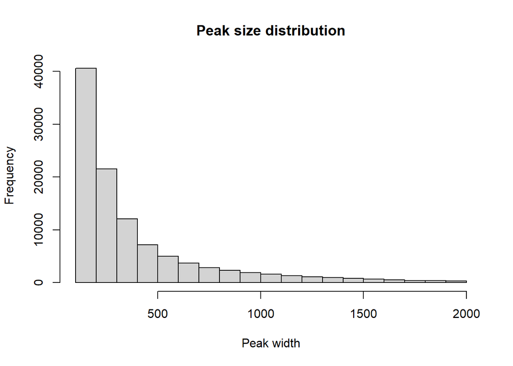

```r
library("plyranges")
#remove peaks with width over 2 kb
rep1_g_f <- plyranges::filter(rep1_g,width<2000)
hist(width(rep1_g_f), main = "Peak size distribution", xlab = "Peak width")
```

```r
print(paste("Filtering for peaks smaller than 2kb removed",length(rep1_g)-length(rep1_g_f),"peaks. These are",round(100*((length(rep1_g)-length(rep1_g_f))/length(rep1_g)),2),"% of peaks.",sep=" "))
```

```
## [1] "Filtering for peaks smaller than 2kb removed 2044 peaks. These are 1.91 % of peaks."
```

#### 10. How does the p-value distribution look like within your replicate?

**Note**: The p-values are not yet part of your metadata.

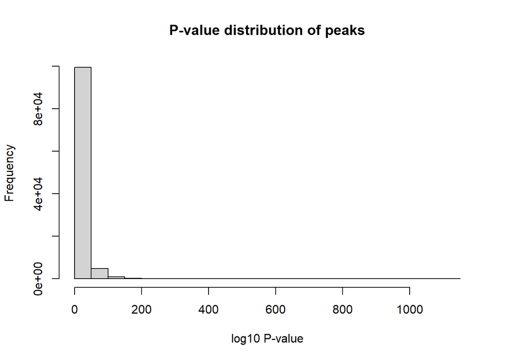

```r
rep1_g <- GRanges(seqnames = rep1$chr,range = IRanges(start = rep1$start, end = rep1$end, names = rep1$name), strand = "*", FC = rep1$`fold-change`, qvalue = rep1$qvalue_log10, pvalue =  rep1$pvalue_log10)
rep1_g_f <- plyranges::filter(rep1_g,width<2000)
hist(mcols(rep1_g_f)$pvalue, main = "P-value distribution of peaks", xlab = "log10 P-value")
```

One big advantage of working with `GRanges` are functions of the `GenomicRanges` package interrogating the sequence position such as overlaps or differences, but also peak width, gaps etc… .  
We will make use of the `subsetByOverlaps` function to determine the overlap of our peaks with ENCODE blacklisted regions and to remove those from our data. Refer to Amemiya et al. Nature 2019 (https://doi.org/10.1038/s41598-019-45839-z) for more details on how those are defined. BED files can be downloaded from github (https://github.com/Boyle-Lab/Blacklist/tree/master/lists). I have added the blacklisted regions for *Hg38* to the ./data/ sub folder (already)“hg38-blacklist.v2.bed”).

#### 1. Import the ENCODe blacklisted regions and convert the into GRanges.

```r
blacklist <- read.table("./data/hg38-blacklist.v2.bed", header = FALSE, stringsAsFactors = FALSE, fill = TRUE)
blacklist_g <- bed2GRanges(blacklist)
```

#### 2. Calculate the percent of overlap of your replicate with ENCODE blacklisted regions using `subsetByOverlaps`.

```r
print(paste(round(100*length(subsetByOverlaps(rep1_g, blacklist_g, minoverlap = 1, ignore.strand = TRUE))/length(rep1_g), 2), "% overlap ENCODE-blacklisted regions.", sep=" "))
```

```
## [1] "0.36 % overlap ENCODE-blacklisted regions."
```

#### 3. Remove the peaks overlapping blacklisted regions and report the number of peaks after filtering.

```r
rep1_g <- subsetByOverlaps(rep1_g,blacklist_g,invert = TRUE, minoverlap = 1, ignore.strand = TRUE)

#print the number of peaks per sample after removal of ENCODE blacklisted regions
print(paste(length(rep1_g), "peaks remain after removal of ENCODE's blacklisted regions.", sep =" "))
```

```
## [1] "106845 peaks remain after removal of ENCODE's blacklisted regions."
```